# Figure 1 - Spatial Figure-1`

Marc Elosua-Bayes

abril 20, 2022

## Introduction

In this script we are going to make the spatial panels for Figure-1

## Libraries

```r
library(Seurat)
library(ggpubr)
library(cowplot)
library(dplyr)
library(ggplot2)
library(stringr)
library(readr)
library(Matrix)
library(SPOTlight)
```

## Setting parameters

Loading necessary paths and parameters

```r
set.seed(123)
source(here::here("misc/paths.R"))
source(here::here("utils/bin.R"))

"{fig1}/{plt_dir}" %>%
  glue::glue() %>%
  here::here() %>%
  dir.create(path = .,
             showWarnings = FALSE,
             recursive = TRUE)

"{fig1}/{robj_dir}" %>%
  glue::glue() %>%
  here::here() %>%
  dir.create(path = .,
             showWarnings = FALSE,
             recursive = TRUE)

clust_vr <- "annotation_figure_1"
```

```r
cols_fig1 <- c(
  "NBC" = "#dcf0f4",
  "Activated NBC" = "#7bc6d6",
  "GCBC" = "#398D9F",
  "MBC" = "#025566",
  "PC" = "#032872",
  "CD4 T" = "#93331b",
  "Naive CD4 T" = "#be8476",
  "Naive CD8 T" = "#e5b7c6",
  "CD8 T" = "#cb708e",
  "NK" = "#67253a",
  "DN" = "#d2a027",
  "ILC" = "#88657f",
  "cycling T"  = "#cc0000",
  "preB/T" = "#4363d8",
  "DC" = "#b6dec3",
  "Mono/Macro" = "#6ac087",
  "Mast" = "#3a8b55",
  "Granulocytes" = "#32d732",
  "cycling myeloid" = "#2b6840",
  "FDC" = "#d5ff00",
  "cycling FDC" = "#bfe600",
  "epithelial" = "#ffdc9f",
  "PDC" = "#f032e6",
  "Cycling" = "lightgrey")

col_df <- data.frame(
  ct = names(cols_fig1),
  ct_mod = str_replace_all(names(cols_fig1), "[[:punct:]]|[[:space:]]", "."),
  color = cols_fig1)
```

## Load data

We have 8 different datasets that we have integrated in previous scripts - *03-clustering/03-clustering_integration.Rmds*. We are going to analyze the integrated dataset all together since the regions are shared across all

```r
# Tonsils integrated
sp_obj <- "misc/{robj_dir}/20220215_tonsil_atlas_spatial_seurat_obj.rds" %>%
  glue::glue() %>%
  here::here() %>%
  readRDS(file = .)

decon_mtrx_ls <- "{fig1}/{robj_dir}/decon_mtrx_{clust_vr}.rds" %>%
  glue::glue() %>%
  here::here() %>%
  readRDS(file = .)
```

## Analysis

Change old names to ones unmodified without dots

```r
decon_mtrx <- decon_mtrx_ls[[2]]
decon_mtrx <- decon_mtrx[, colnames(decon_mtrx) != "res_ss"]
decon_mtrx <- decon_mtrx[, !is.na(colnames(decon_mtrx))]

# Set as 0 cell types predicted to be under 3 % of the spot
decon_mtrx[decon_mtrx < 0.03] <- 0

# new_colnames <- data.frame(ct_name = colnames(decon_mtrx),
#                            stringsAsFactors = FALSE) %>%
#   dplyr::left_join(col_df, by = c("ct_name" = "ct_mod")) %>%
#   dplyr::pull(ct)

# colnames(decon_mtrx) <- new_colnames
```

We are going to add the deconvolution to the Seurat object.

```r
sp_obj@meta.data <- cbind(sp_obj@meta.data, decon_mtrx)
```

Save the seurat object with the predicted cell-type proportions

```r
"{fig1}/{robj_dir}/se_deconv_{clust_vr}.rds" %>%
  glue::glue() %>%
  here::here() %>%
  saveRDS(
    object = sp_obj,
    file = .)
```

### Clustering

Subset slide of interest

```r
i <- "esvq52_nluss5"
print(i)
```

```
## [1] "esvq52_nluss5"
```

```r
# Subset sp object
keep <- sp_obj$gem_id == i
sp_sub <- sp_obj[, names(keep[keep])]
```

### Visualization

#### Cell type location

Look at the location of each cell type in each slice separately

```r
ct <- colnames(decon_mtrx)

# https://stackoverflow.com/questions/38722202/how-do-i-change-the-number-of-decimal-places-on-axis-labels-in-ggplot2
# Our transformation function to ensure 2 decimals in the legend
scaleFUN <- function(x) sprintf("%.2f", x)

# Iterate over imagesample_id
# lapply(id_sp_df$gem_id, function(i) {
# i <- "esvq52_nluss5"
# print(i)
# # Subset sp object
# sp_sub <- subset(sp_obj, subset = gem_id == i)

# Set filename
donor <- id_sp_df %>%
dplyr::filter(gem_id == i) %>%
  dplyr::pull(donor_id)

fn <- "{fig1}/{plt_dir}/{i}_{clust_vr}_celltype.pdf" %>%
glue::glue() %>%
here::here()

# Iterate over cell types
lapply(ct, function(ii) {
  tmp_plt <- Seurat::SpatialFeaturePlot(
    object = sp_sub,
    features = ii,
    alpha = c(0.1, 1),
    images = i)

if (sum(sp_sub@meta.data[, ii]) == 0) {
  tmp_plt <- tmp_plt + ggplot2::scale_alpha(range = c(0,0))
} else {
  tmp_plt <- tmp_plt + ggplot2::scale_alpha(range = c(0, 1))
}

  tmp_plt <- tmp_plt +
    ggplot2::theme(legend.title = ggplot2::element_blank()) +
    ggplot2::labs(title = ii) +
    ggplot2::scale_fill_gradientn(
      colors = grDevices::heat.colors(10, rev = TRUE),
      # Same number of breaks for all plots
      breaks = seq(min(sp_sub@meta.data[, ii]),
                   max(sp_sub@meta.data[, ii]),
                   length.out = 4),
      limits = c(0, max(sp_sub@meta.data[, ii])),
      # 2 decimals in the legend
      labels = scaleFUN
      # limits = c(0, 1)
    )
  tmp_plt
}) %>%
  cowplot::plot_grid(
    plotlist = .,
    align = "hv",
    axis = "trbl") %>%
  cowplot::save_plot(
    filename = fn,
    plot = .,
    base_height = 25,
    base_width = 25)
# })
```

#### Spatial scatterpie

```r
# lapply(id_sp_df$gem_id, function(i) {
# print(i)
# Subset sp object
# sp_sub <- subset(sp_obj, subset = gem_id == i)

sct_plt <- SPOTlight::scatterpie_plot(
  se_obj = sp_sub,
  cell_types_all = ct,
  pie_scale = 0.425,
  slice = i) +
  ggplot2::scale_fill_manual(
    values = col_df[col_df$ct_mod %in% ct, "color"],
    breaks = col_df[col_df$ct_mod %in% ct, "ct_mod"],
    labels = stringr::str_wrap(string = col_df[col_df$ct_mod %in% ct, "ct"],
                               width = 25)) +
  ggplot2::coord_fixed(ratio = 1) +
  ggplot2::theme(
    legend.position = "top",
    legend.text = ggplot2::element_text(size = 12),
    legend.title = ggplot2::element_blank()) +
  ggplot2::guides(fill = ggplot2::guide_legend(nrow = 3, byrow = TRUE))

# sct_plt

# Set filename
"{fig1}/{plt_dir}/{i}_{clust_vr}_scatterpie_allct.pdf" %>%
  glue::glue() %>%
  here::here() %>%
  cowplot::save_plot(
    filename = .,
    plot = sct_plt,
    base_width = 9,
    base_height = 9)

"{fig1}/{plt_dir}/{i}_{clust_vr}_scatterpie_allct.rds" %>%
  glue::glue() %>%
  here::here() %>%
  saveRDS(
    object = sct_plt,
    file = .)
```

We can also take a look at the spatial scatterpie by looking at cell types which are not present throughout the entire tissue.

```
## [1] "tarwe1_xott6q"
```

```
## [1] "c28w2r_7jne4i"
```

```
## [1] "esvq52_nluss5"
```

```
## [1] "p7hv1g_tjgmyj"
```

```
## [1] "gcyl7c_cec61b"
```

```
## [1] "zrt7gl_lhyyar"
```

```
## [1] "qvwc8t_2vsr67"
```

```
## [1] "exvyh1_66caqq"
```

[output not shown]

#### Cell-Cell correlation plot

By looking at correlations we want to assess if there are cell types which are correlating in space. So when one is present is another one also present?

We will be using `ggcorrplot` to show these correlation plots a bit nicer: http://www.sthda.com/english/wiki/ggcorrplot-visualization-of-a-correlation-matrix-using-ggplot2

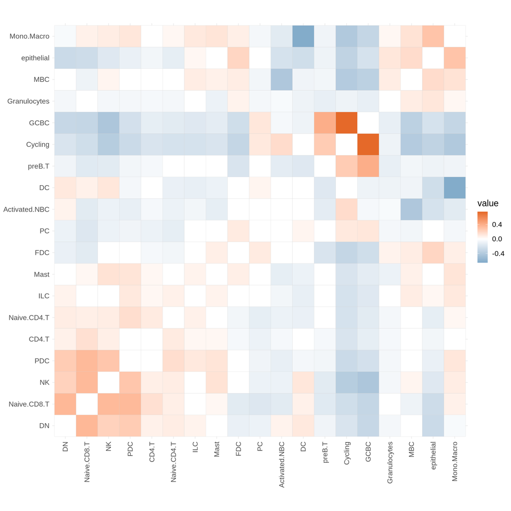